# House Price Forecasting Through a Multiple Linear Regression

The purpose of this project is to predict a house price of unit area based on several house parameters. In this case Multiple Linear Regression is the best option to create an accurate model.

### Importing libraries

```python
from sklearn.model_selection import train_test_split
from sklearn.linear_model import LinearRegression

from sklearn.linear_model import SGDRegressor
from sklearn.model_selection import GridSearchCV

import pandas as pd
import numpy as np
import matplotlib.pyplot as plt
import seaborn as sns

import statsmodels.api as sm
from statsmodels.stats.outliers_influence import variance_inflation_factor

import warnings
warnings.filterwarnings("ignore")

%matplotlib inline
```

### Reading the data set

```python
data = pd.read_csv(r"C:\Users\SilkRIT\Desktop\разное\ML_stepik\multilinear regression\Real_estate.csv")
```

### Data preparation

Let's have a look at the data. Here we can see the dataframe with variables which column name starts with "X" and target column "Y house price of unit area".

```python
data.describe()
```

|  | No | X1 transaction date | X2 house age | X3 distance to the nearest MRT station | X4 number of convenience stores | X5 latitude | X6 longitude | Y house price of unit area |
| --- | --- | --- | --- | --- | --- | --- | --- | --- |
| count | 414.000000 | 414.000000 | 414.000000 | 414.000000 | 414.000000 | 414.000000 | 414.000000 | 414.000000 |
| mean | 207.500000 | 2013.148971 | 17.712560 | 1083.885689 | 4.094203 | 24.969030 | 121.533361 | 37.980193 |
| std | 119.655756 | 0.281967 | 11.392485 | 1262.109595 | 2.945562 | 0.012410 | 0.015347 | 13.606488 |
| min | 1.000000 | 2012.667000 | 0.000000 | 23.382840 | 0.000000 | 24.932070 | 121.473530 | 7.600000 |
| 25% | 104.250000 | 2012.917000 | 9.025000 | 289.324800 | 1.000000 | 24.963000 | 121.528085 | 27.700000 |
| 50% | 207.500000 | 2013.167000 | 16.100000 | 492.231300 | 4.000000 | 24.971100 | 121.538630 | 38.450000 |
| 75% | 310.750000 | 2013.417000 | 28.150000 | 1454.279000 | 6.000000 | 24.977455 | 121.543305 | 46.600000 |
| max | 414.000000 | 2013.583000 | 43.800000 | 6488.021000 | 10.000000 | 25.014590 | 121.566270 | 117.500000 |

```python
data.head()
```

|  | No | X1 transaction date | X2 house age | X3 distance to the nearest MRT station | X4 number of convenience stores | X5 latitude | X6 longitude | Y house price of unit area |
| --- | --- | --- | --- | --- | --- | --- | --- | --- |
| 0 | 1 | 2012.917 | 32.0 | 84.87882 | 10 | 24.98298 | 121.54024 | 37.9 |
| 1 | 2 | 2012.917 | 19.5 | 306.59470 | 9 | 24.98034 | 121.53951 | 42.2 |
| 2 | 3 | 2013.583 | 13.3 | 561.98450 | 5 | 24.98746 | 121.54391 | 47.3 |
| 3 | 4 | 2013.500 | 13.3 | 561.98450 | 5 | 24.98746 | 121.54391 | 54.8 |
| 4 | 5 | 2012.833 | 5.0 | 390.56840 | 5 | 24.97937 | 121.54245 | 43.1 |

Checking whether data has null values or not.

```python
pd.isnull(data).any()
```

```
No                                        False
X1 transaction date                       False
X2 house age                              False
X3 distance to the nearest MRT station    False
X4 number of convenience stores           False
X5 latitude                               False
X6 longitude                              False
Y house price of unit area                False
dtype: bool
```

```python
data.info()
```

```
<class 'pandas.core.frame.DataFrame'>
RangeIndex: 414 entries, 0 to 413
Data columns (total 8 columns):
 #   Column                                  Non-Null Count  Dtype
---  ------                                  --------------  -----
 0   No                                      414 non-null    int64
 1   X1 transaction date                     414 non-null    float64
 2   X2 house age                            414 non-null    float64
 3   X3 distance to the nearest MRT station  414 non-null    float64
 4   X4 number of convenience stores         414 non-null    int64
 5   X5 latitude                             414 non-null    float64
 6   X6 longitude                            414 non-null    float64
 7   Y house price of unit area              414 non-null    float64
dtypes: float64(6), int64(2)
memory usage: 26.0 KB
```

Analysing the distribution of price of unit area. It's likely to be normal with skewness.

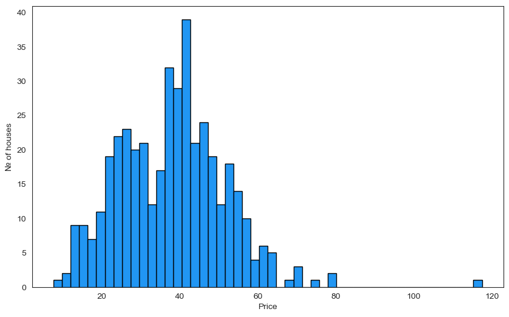

```python
plt.figure(figsize =(10,6))
plt.hist(data['Y house price of unit area'], bins = 50, ec= 'black', color = '#2196f3')
plt.xlabel('Price')
plt.ylabel('№ of houses')
plt.show()
```

Next I want to see the distribution of variable Distance to the nearest MRT station.

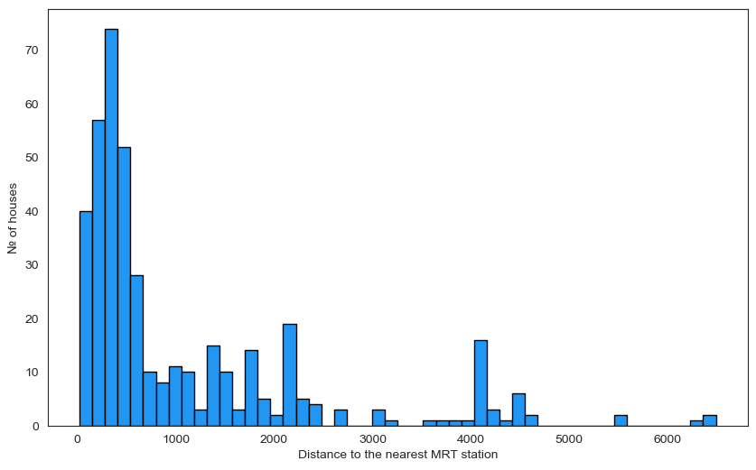

```python
plt.figure(figsize =(10,6))
plt.hist(data['X3 distance to the nearest MRT station'], bins = 50, ec= 'black', color = '#2196f3')
plt.xlabel('Distance to the nearest MRT station')
plt.ylabel('№ of houses')
plt.show()
```

And now we may calculate the correlation coefficient of variables. One option is to do it manualy one by one.

```python
data['Y house price of unit area'].corr(data['X3 distance to the nearest MRT station'])
```

```
-0.6736128553689182
```

```python
data['Y house price of unit area'].corr(data['X4 number of convenience stores'])
```

```
0.5710049111111483
```

The other option is to use pandas tool corr which provides every correlation between variables.

```python
data.corr()
```

|  | No | X1 transaction date | X2 house age | X3 distance to the nearest MRT station | X4 number of convenience stores | X5 latitude | X6 longitude | Y house price of unit area |
| --- | --- | --- | --- | --- | --- | --- | --- | --- |
| No | 1.000000 | -0.048658 | -0.032808 | -0.013573 | -0.012699 | -0.010110 | -0.011059 | -0.028587 |
| X1 transaction date | -0.048658 | 1.000000 | 0.017549 | 0.060880 | 0.009635 | 0.035058 | -0.041082 | 0.087491 |
| X2 house age | -0.032808 | 0.017549 | 1.000000 | 0.025622 | 0.049593 | 0.054420 | -0.048520 | -0.210567 |
| X3 distance to the nearest MRT station | -0.013573 | 0.060880 | 0.025622 | 1.000000 | -0.602519 | -0.591067 | -0.806317 | -0.673613 |
| X4 number of convenience stores | -0.012699 | 0.009635 | 0.049593 | -0.602519 | 1.000000 | 0.444143 | 0.449099 | 0.571005 |
| X5 latitude | -0.010110 | 0.035058 | 0.054420 | -0.591067 | 0.444143 | 1.000000 | 0.412924 | 0.546307 |
| X6 longitude | -0.011059 | -0.041082 | -0.048520 | -0.806317 | 0.449099 | 0.412924 | 1.000000 | 0.523287 |
| Y house price of unit area | -0.028587 | 0.087491 | -0.210567 | -0.673613 | 0.571005 | 0.546307 | 0.523287 | 1.000000 |

I will build the heatmap to understand correlations better.

```python
mask = np.zeros_like(data.corr())
triangle_indices = np.triu_indices_from(mask)
mask[triangle_indices] = True
mask
```

```
array([[1., 1., 1., 1., 1., 1., 1., 1.],
       [0., 1., 1., 1., 1., 1., 1., 1.],
       [0., 0., 1., 1., 1., 1., 1., 1.],
       [0., 0., 0., 1., 1., 1., 1., 1.],
       [0., 0., 0., 0., 1., 1., 1., 1.],
       [0., 0., 0., 0., 0., 1., 1., 1.],
       [0., 0., 0., 0., 0., 0., 1., 1.],
       [0., 0., 0., 0., 0., 0., 0., 1.]])
```

On this heatmap we may see how variables influence on target value. The greater the absolute value of the coefficient, the greater the influence of the variable on the desired value. Also variables may be influenced by each other, for example longitude and distance to the nearest MRT station. It may lead to wrong model setup.

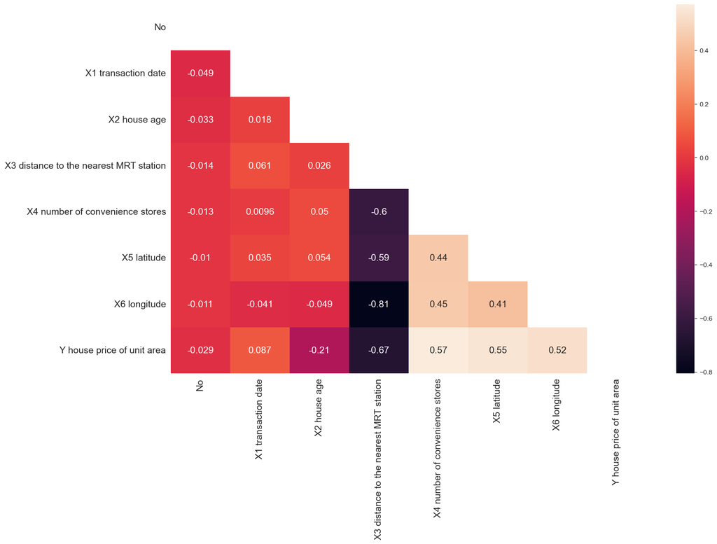

```python
plt.figure(figsize =(16,10))
sns.heatmap(data.corr(), mask= mask, annot = True, annot_kws= {"size" : 14})
sns.set_style('white')
plt.xticks(fontsize = 14)
plt.yticks(fontsize = 14)
plt.show()
```

Now I will build the scatter plot with correlation of distance to the nearest MRT station and price and then create the trend line.

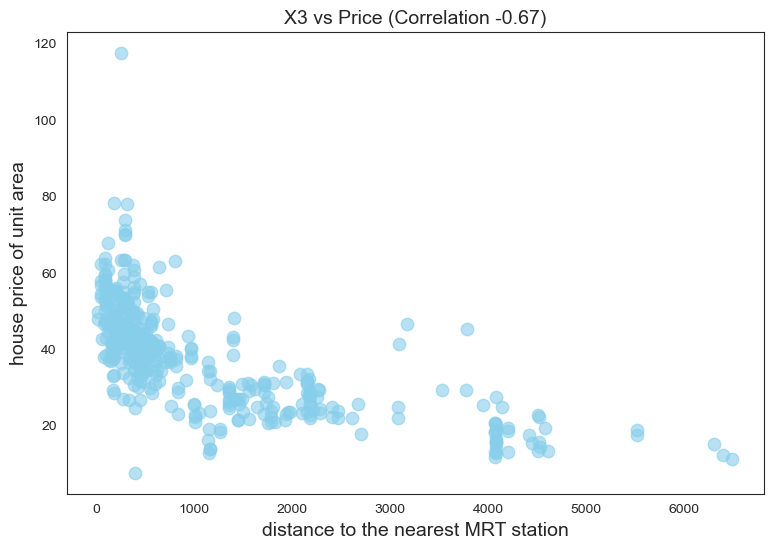

```python
x3_y_corr = round(data['X3 distance to the nearest MRT station'].corr(data['Y house price of unit area']),2)

plt.figure(figsize = (9,6))
plt.scatter(x= data['X3 distance to the nearest MRT station'],
            y = data['Y house price of unit area'], alpha = 0.6, s=80, color ='skyblue')

plt.title(f'X3 vs Price (Correlation {x3_y_corr})', fontsize = 14)
plt.xlabel('distance to the nearest MRT station', fontsize = 14)
plt.ylabel('house price of unit area', fontsize = 14)

plt.show()
```

This way I can see the negative relationship between two variables.

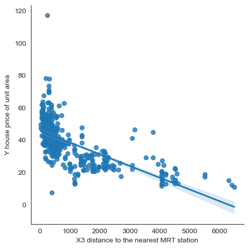

```python
sns.lmplot(x = 'X3 distance to the nearest MRT station', y ='Y house price of unit area',data = data)
plt.show()
```

### Data modeling

First, we need to split the data on train and test samples

```python
prices = data['Y house price of unit area']
features = data.drop(['Y house price of unit area','No'], axis = 1)

X_train, X_test, y_train, y_test = train_test_split(features, prices, test_size = 0.2, random_state=10)
```

Then I create the Linear Regression model, fit it and check the r-squared. Test data r-squared is 0.59, let's try to increase it.

```python
regr = LinearRegression()
regr.fit(X_train, y_train)

print('Training data r-squared:', regr.score(X_train, y_train))
print('Test data r-squared:', regr.score(X_test, y_test))

print('Intercept:', regr.intercept_)
pd.DataFrame(data= regr.coef_, index = X_train.columns, columns = ['coef'])
```

```
Training data r-squared: 0.5754576515689835
Test data r-squared: 0.5941247122614592
Intercept: -17660.930364000356
```

|  | coef |
| --- | --- |
| X1 transaction date | 6.142954 |
| X2 house age | -0.268205 |
| X3 distance to the nearest MRT station | -0.004159 |
| X4 number of convenience stores | 1.117129 |
| X5 latitude | 225.982451 |
| X6 longitude | -2.517430 |

We may start with checking the skewness of prices and then take logarithm of them.

```python
data['Y house price of unit area'].skew()
```

```
0.5998525842660576
```

```python
data['Y house price of unit area'].min
```

```
<bound method NDFrame._add_numeric_operations.<locals>.min of 0      37.9
1      42.2
2      47.3
3      54.8
4      43.1
       ...
409    15.4
410    50.0
411    40.6
412    52.5
413    63.9
Name: Y house price of unit area, Length: 414, dtype: float64>
```

```python
y_log = np.log(data['Y house price of unit area'])
y_log.tail()
```

```
409    2.734368
410    3.912023
411    3.703768
412    3.960813
413    4.157319
Name: Y house price of unit area, dtype: float64
```

```python
y_log.skew()
```

```
-0.7063995221097437
```

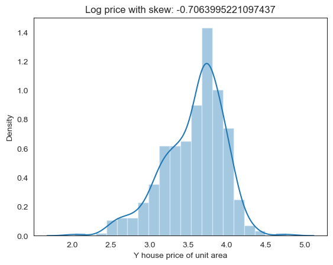

```python
sns.distplot(y_log)
plt.title(f'Log price with skew: {y_log.skew()}')
plt.show()
```

Let's see what happend to r-squared of price logs. Test data r-squared increased to 0.71.

```python
prices = np.log(data['Y house price of unit area'])
features = data.drop(['Y house price of unit area','No'], axis = 1)

X_train, X_test, y_train, y_test = train_test_split(features, prices, test_size = 0.2, random_state=10)

regr = LinearRegression()
regr.fit(X_train, y_train)

print('Training data r-squared:', regr.score(X_train, y_train))
print('Test data r-squared:', regr.score(X_test, y_test))

print('Intercept:', regr.intercept_)
pd.DataFrame(data= regr.coef_, index = X_train.columns, columns = ['coef'])
```

```
Training data r-squared: 0.6775693845474321
Test data r-squared: 0.7088230662651924
Intercept: -602.2452149780239
```

|  | coef |
| --- | --- |
| X1 transaction date | 0.151632 |
| X2 house age | -0.006871 |
| X3 distance to the nearest MRT station | -0.000136 |
| X4 number of convenience stores | 0.027103 |
| X5 latitude | 8.162146 |
| X6 longitude | 0.797321 |

Next step is to evaluate the P-value of each variable. P-value higher than 0.05 indicates than variable insignificant in our model. In our case it's longitude with 0.559 P-value.

```python
X_incl_const = sm.add_constant(X_train)

model = sm.OLS(y_train,X_incl_const)
results = model.fit()

pd.DataFrame({'coef' : results.params, 'p-value' : round(results.pvalues, 3)})
```

|  | coef | p-value |
| --- | --- | --- |
| const | -602.245215 | 0.002 |
| X1 transaction date | 0.151632 | 0.001 |
| X2 house age | -0.006871 | 0.000 |
| X3 distance to the nearest MRT station | -0.000136 | 0.000 |
| X4 number of convenience stores | 0.027103 | 0.000 |
| X5 latitude | 8.162146 | 0.000 |
| X6 longitude | 0.797321 | 0.559 |

To make sure that dropping longitude will not change our model we also need to check BIC value. BIC (Bayesian Information Criteria) estimates the likelihood of a model to predict. There is no explicitly 'good' BIC value. BIC values need to be compared. The best model for the data is the one with the lowest BIC value. So let's compare BIC and r-squared with and without longitude.

```python
X_incl_const = sm.add_constant(X_train)

model = sm.OLS(y_train,X_incl_const)
results = model.fit()

org_coef = pd.DataFrame({'coef' : results.params, 'p-value' : round(results.pvalues, 3)})

print('BIC is:', results.bic)
print('r-squared is:', results.rsquared)
```

```
BIC is: -5.013664003200915
r-squared is: 0.6775693845474315
```

```python
X_incl_const = sm.add_constant(X_train)
X_incl_const = X_incl_const.drop(['X6 longitude'], axis = 1)

model = sm.OLS(y_train,X_incl_const)
results = model.fit()

reduced_coef = pd.DataFrame({'coef' : results.params, 'p-value' : round(results.pvalues, 3)})
print('BIC is:', results.bic)
print('r-squared is:', results.rsquared)
```

```
BIC is: -10.46673076643583
r-squared is: 0.6772291903227673
```

Now we see that creating model without longitude variable doesn't lead to r-squared reduction, but reduces the BIC.

```python
frames = [org_coef, reduced_coef]
pd.concat(frames,axis = 1)
```

|  | coef | p-value | coef | p-value |
| --- | --- | --- | --- | --- |
| const | -602.245215 | 0.002 | -503.403960 | 0.000 |
| X1 transaction date | 0.151632 | 0.001 | 0.151758 | 0.001 |
| X2 house age | -0.006871 | 0.000 | -0.006902 | 0.000 |
| X3 distance to the nearest MRT station | -0.000136 | 0.000 | -0.000144 | 0.000 |
| X4 number of convenience stores | 0.027103 | 0.000 | 0.026949 | 0.000 |
| X5 latitude | 8.162146 | 0.000 | 8.074728 | 0.000 |
| X6 longitude | 0.797321 | 0.559 | NaN | NaN |

Then I plot the residuals of model. The main idea is to make sure that there is no tendency in correlation between residuals and predicted values. As you can see in our model residuals don't depend on predicted prices.

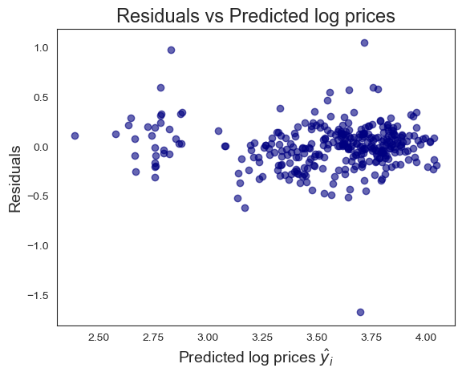

```python
prices = np.log(data['Y house price of unit area'])
features = data.drop(['Y house price of unit area','No', 'X6 longitude'], axis = 1)

X_train, X_test, y_train, y_test = train_test_split(features, prices, test_size = 0.2, random_state=10)
X_incl_const = sm.add_constant(X_train)
model = sm.OLS(y_train,X_incl_const)
results = model.fit()

plt.scatter(x= results.fittedvalues, y = results.resid, c = 'navy', alpha = 0.6)

plt.xlabel('Predicted log prices $\hat y _i$', fontsize = 14)
plt.ylabel('Residuals', fontsize = 14)
plt.title('Residuals vs Predicted log prices', fontsize = 17)

plt.show()
```

Distribution of residuals is normal with zero mean value.

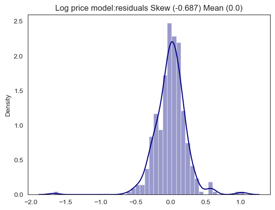

```python
resid_mean = round(results.resid.mean(),3)
resid_skew = round(results.resid.skew(),3)

sns.distplot(results.resid, color = 'navy')
plt.title(f'Log price model:residuals Skew ({resid_skew}) Mean ({resid_mean})')

plt.show()
```

Before giving the answer about predicted price per unit area it is more correctly to evaluate confidence interval (+/- 2 std). For example, if our model predictes 30$ price per unit area the interval will be:

```python
reduced_log_mse = round(results.mse_resid, 3)

print('Evaluating interval for predicted 30$ price per unit area value with 95% accuracy:')

print(f'2 standart diviations in logs', 2*np.sqrt(reduced_log_mse))

upper_bound = np.log(30) + 2*np.sqrt(reduced_log_mse)
print('The upper bound in normal prices is $', np.e**upper_bound)

lower_bound = np.log(30) - 2*np.sqrt(reduced_log_mse)
print('The upper bound in normal prices is $', np.e**lower_bound)
```

```
Evaluating interval for predicted 30$ price per unit area value with 95% accuracy:
2 standart diviations in logs 0.45607017003965516
The upper bound in normal prices is $ 47.33583178365353
The upper bound in normal prices is $ 19.013080917504794
```